# R: Tidyverse

## Séparer des colonnes (*spread*)

Crée une colonne par modalité d’une variable

## Valeurs manquantes

Les valeurs manquantes explicites (valeur `NA`) peuvent être conservées dans les manipulations ou simplement supprimées avec l’option `na.rm=TRUE`.

`complete(var1, var2)` ajoute des enregistrements pour toutes les combinaisons de var1 et var2 manquantes.

[Référence](http://r4ds.had.co.nz/tidy-data.html#missing-values-3)

## Transformation

Outils du package *dplyr*

Idée :

- enchaîner les opérations de transformation avec les `%>%` ;
- les écrire et les tester une à une.

## Filtrer les lignes (*filter*)

Filtrer par des conditions sur les différentes variables

```r
# Nombre de lignes
Paracou6 %>% count %>% pull
```

```
## [1] 3620
```

```r
# Après filtrage
Paracou6 %>% filter(SubPlot == 1 & CodeAlive == TRUE) %>%
    count %>% pull
```

```
## [1] 942
```

Remarquer : `pull()`qui extrait la valeur finale du tibble de taille 1x1 produit par `count()`.

## Sélectionner les colonnes (*select*)

Ne retenir que les colonnes intéressantes

```r
Paracou6 %>% select(SubPlot:Yfield, Family:Species,
    CircCorr) %>% ncol
```

```
## [1] 11
```

Remarquer : `ncol()` est une fonction de *base*, pas du tidyverse.

## Ajouter des variables calculées (*mutate*)

Des colonnes sont ajoutées au tibble

```r
(Paracou6Taille <- Paracou6 %>% select(idTree, CircCorr) %>%
    mutate(Diametre = CircCorr/pi))
```

```
## # A tibble: 3,620 x 3
##   idTree CircCorr Diametre
##    <int>    <dbl>    <dbl>
## 1 100678    134.      42.8
## 2 100681     59.      18.8
## 3 100682     36       11.5
## 4 100683     55.0     17.5
## 5 100684     51       16.2
## # ... with 3,615 more rows
```

Remarquer : les parenthèses pour `print()`

## Trier les lignes (*arrange*)

Afficher les plus gros arbres de la parcelle :

```r
Paracou6Taille %>% arrange(desc(CircCorr))
```

```
## # A tibble: 3,620 x 3
##   idTree CircCorr Diametre
##    <int>    <dbl>    <dbl>
## 1 104455     318     101.
## 2 103939     317     101.
## 3 102249     300.     95.3
## 4 102086     290      92.3
## 5 100904     288.     91.8
## # ... with 3,615 more rows
```

## Regrouper et résumer

Quel est le diamètre moyen des arbres par famille ?

```r
Paracou6 %>% group_by(Family) %>% summarise(Dmean = mean(CircCorr)/pi,
    NbTrees = length(idTree)) %>% arrange(desc(Dmean))
```

```
## # A tibble: 51 x 3
##   Family         Dmean NbTrees
##   <chr>          <dbl>   <int>
## 1 Vochysiaceae    49.2      11
## 2 Combretaceae    48.4       2
## 3 Phyllanthaceae  41.9       3
## 4 Humiriaceae     38.6      20
## 5 Goupiaceae      37.4      19
## # ... with 46 more rows
```

## Visualisation

## *ggplot2*

Package destiné à la création de graphiques.

Respecte la [grammaire graphique par couches](http://vita.had.co.nz/papers/layered-grammar.pdf) :

```
ggplot(data = <DATA>) +
  <GEOM_FUNCTION>(
     mapping = aes(<MAPPINGS>),
     stat = <STAT>,
     position = <POSITION>
  ) +
  <COORDINATE_FUNCTION> +
  <FACET_FUNCTION>
```

Les données sont obligatoirement un dataframe (un tibble est un dataframe).

## Esthétique

L’esthétique désigne ce qui est représenté :

- `x` et `y` (ou `fill` pour un histogramme…)
- transparence, couleur, type de courbe, taille, … : voir l’aide de chaque `geom_`.

Fonction `aes()` à plusieurs niveaux :

- argument `mapping` de `ggplot()`, hérité par les couches (`geom_`)
- argument `mapping` de chaque couche.

## Géométrie

La géométrie est définie par une fonction `geom_xxx` et une esthétique (ce qui est représenté).

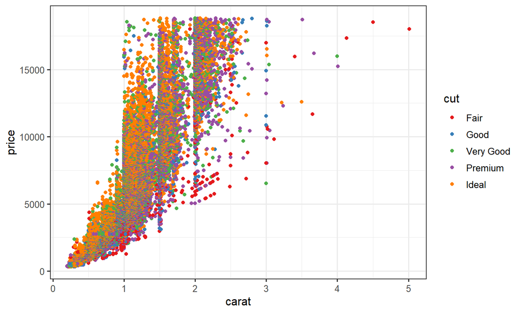

```r
ggplot(data = diamonds) + geom_point(mapping = aes(x = carat,
    y = price, color = cut)) + scale_colour_brewer(palette = "Set1")
```

## Statistiques

Chaque `geom_` va de pair avec une statistique de transformation des données :

- “identity” pour `geom_point`
- “boxplot” pour `geom_boxplot`
- 20 statistiques disponibles…

## Statistiques

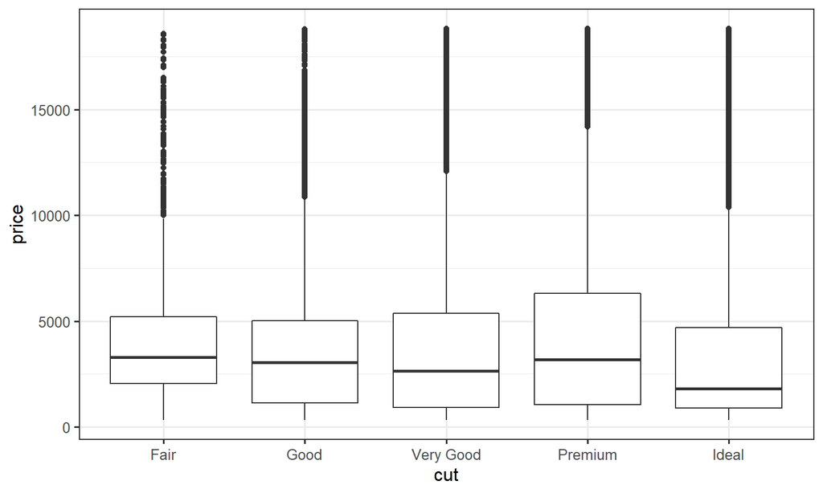

```r
ggplot(data = diamonds) + geom_boxplot(mapping = aes(x = cut,
    y = price))
```

## Statistiques

Différent de la transformation de variables (cf. *scale*) : le graphique utilise des données dérivées des données originales.

Chaque statistique a un `geom_` par défaut :

`stat_summary` est interchangeable avec `geom_pointrange`

## Statistiques

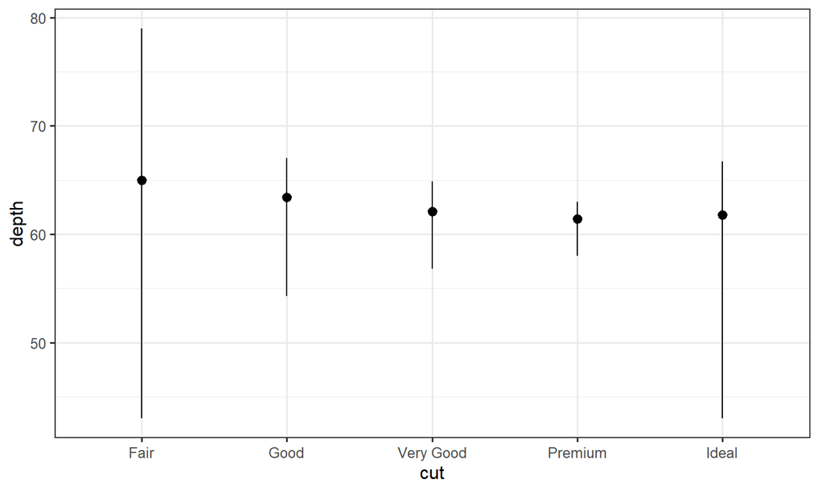

```r
ggplot(data = diamonds) + stat_summary(mapping = aes(x = cut,
    y = depth), fun.ymin = min, fun.ymax = max, fun.y = median)
```

## Echelle

Transformation de variable.

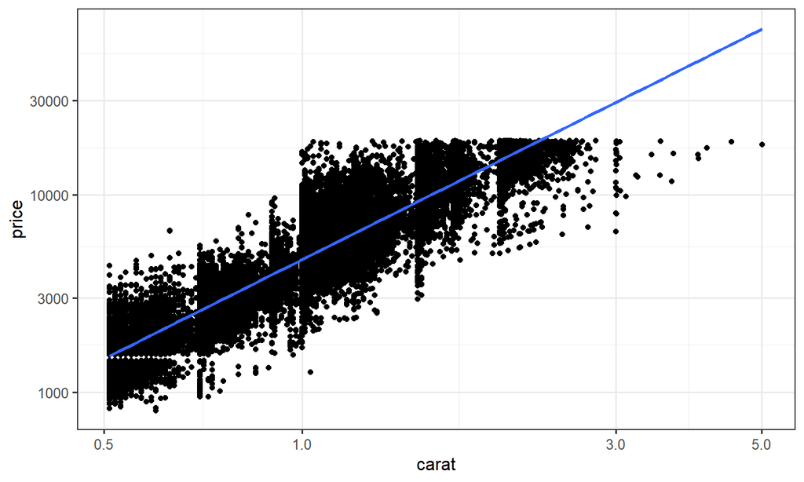

```r
diamonds %>% filter(carat > 0.5) %>% ggplot(aes(x = carat,
    y = price)) + geom_point() + scale_x_log10() +
    scale_y_log10() + geom_smooth(method = "lm")
```

## Position

La position définit l’emplacement des objets sur le graphique.

- “identity” en général
- “stack” empile les catégories dans un histogramme
- “jitter” déplace aléatoirement les points dans un `geom_point` pour éviter les superpositions.

## Position

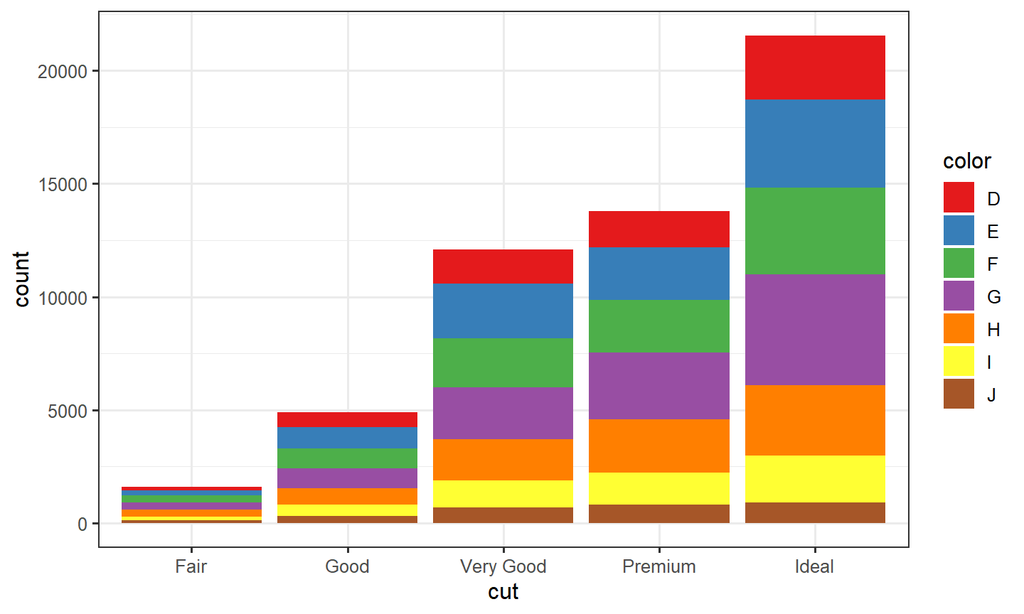

```r
ggplot(data = diamonds) +
  geom_bar(mapping = aes(x = cut, fill = color), position="stack") +
  scale_fill_brewer(palette = "Set1")
```

## Coordonnées

Système de coordonnées :

- `coord_flip()` intervertit `x` et `y`
- `coord_polar()` : coordonnées polaires
- `coord_trans()` transforme l’affichage des coordonnées (mais pas les données comme `scale_`)
- etc.

Exemple : tracer la carte des wapas de la parcelle 6.

## Coordonnées

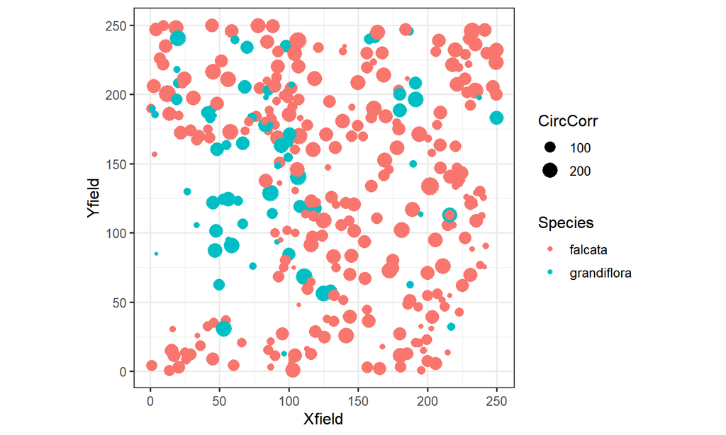

```r
(P6Map <- Paracou6 %>% filter(Genus == "Eperua") %>%
    ggplot() + geom_point(aes(x = Xfield, y = Yfield,
    size = CircCorr, color = Species)) + coord_fixed())
```

## Facettes

Présente plusieurs aspects du même graphique

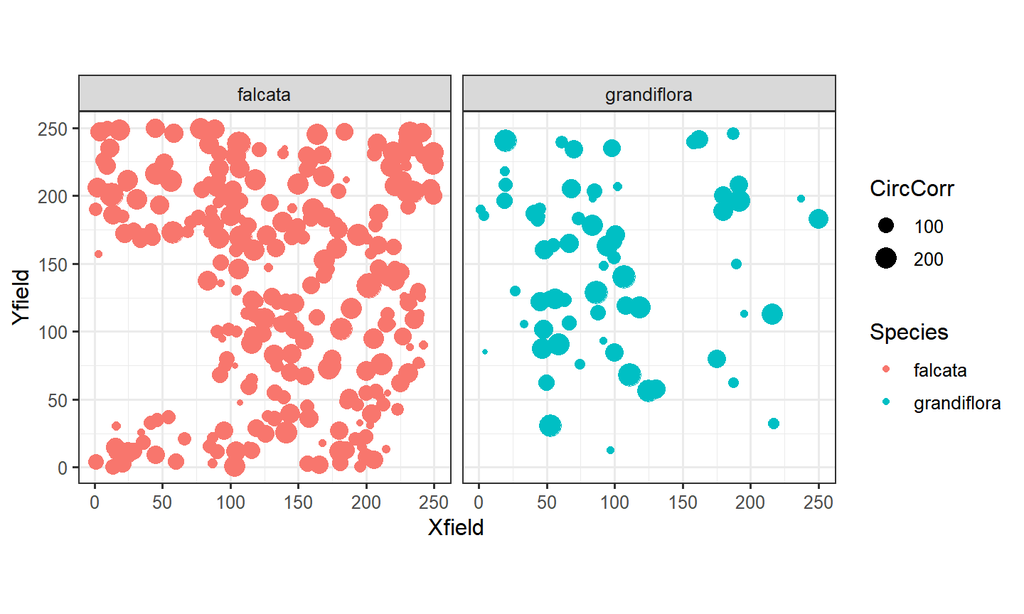

```r
P6Map + facet_wrap(~Species)
```

Remarquer : la possibilité d’affiner un graphique

## Thèmes

Les thèmes définissent l’aspect des graphiques (hors traitement des données)

Dans ce document : pas de fond grisé dans les graphiques (`theme_bw`), police 12, modifié pour que le fond soit transparent:

```r
theme_set(theme_bw(base_size = 12))
theme_update(panel.background = element_rect(fill = "transparent",
    colour = NA), plot.background = element_rect(fill = "transparent",
    colour = NA))
```

Ce sont des options globales, valides pour la session R en cours.

## Styles

Possibilité d’enregistrer des paramètres de forme au-delà du thème dans une liste.

Préparation d’un style pour l’impression en noir et blanc, sans cartouches de légende.

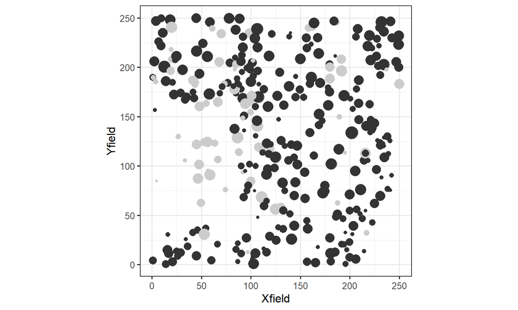

```r
MyStyle <- list(scale_colour_grey(), theme(legend.position = "none"))
P6Map + MyStyle
```

## Gestion des couleurs

Les couleurs par défaut sont assez laides.

Utiliser `scale_color_xxx` et `scale_fill_xxx`

Le suffixe `_brewer` est pour utiliser des palettes de [ColorBrewer](http://colorbrewer2.org)

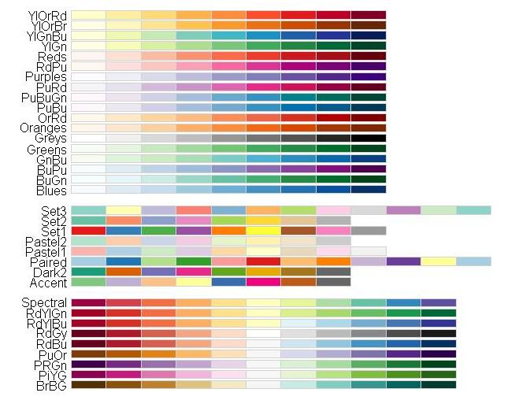

## Gestion des couleurs

Le suffixe `_gradient` permet de produire un gradient de couleurs pour les valeurs continues.

Voir les autres fonctions dans l’aide du package.

- Méthode : se créer progressivement des styles (par ex. : couleur et noir et blanc), les enregistrer et les utiliser systématiquement.

## autoplot et qplot

`qplot()` mime la syntaxe de `plot()` avec *ggplot2*. Utiliser plutôt la syntaxe native.

`autoplot()` est un générique à étendre par des méthodes S3 pour faire des graphiques ggplot. Exemple:

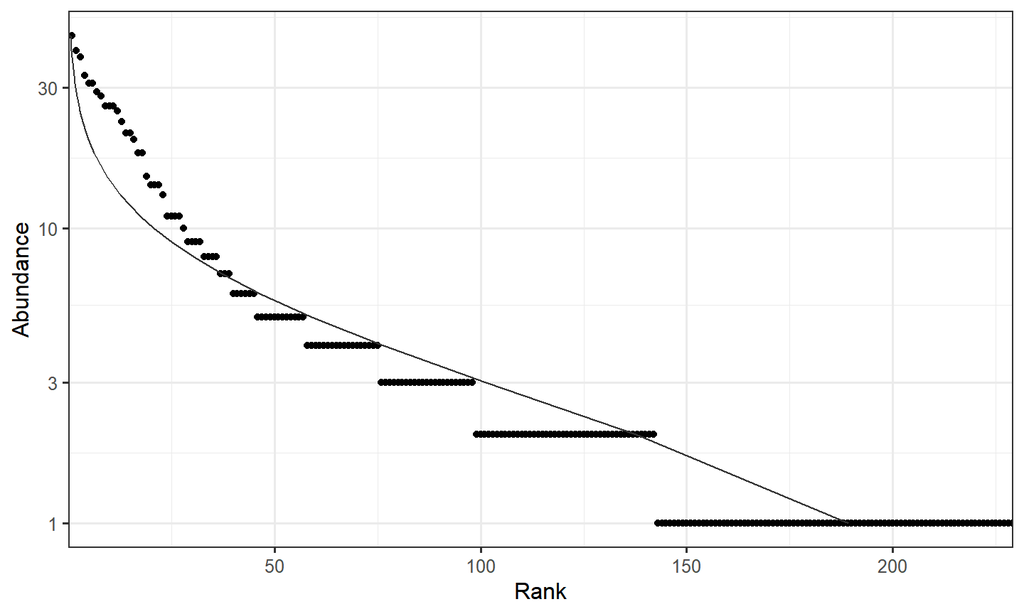

```r
library("entropart")
Paracou618.MC$Ns %>% as.AbdVector %>%
  autoplot(Distribution = "lnorm") + MyStyle
```

## Anti-sèche et extensions

[Anti-sèche sur RStudio](https://www.rstudio.com/wp-content/uploads/2015/03/ggplot2-cheatsheet.pdf)

De nombreux packages étendent *ggplot2* avec de nouveaux `geom_`. Exemple de *ggraph* :

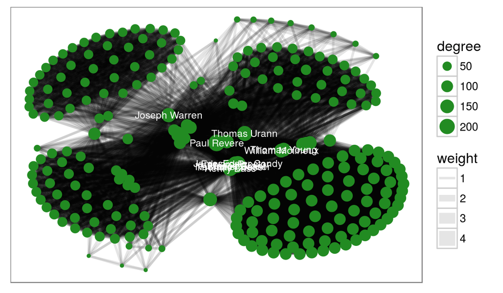